# Customer Churn Prediction — Logistic Regression

A Teaching Notebook | R Studio

Your Name

2026-04-21

# 1 🎯 Objective

We want to predict whether a telecom customer will **churn** (cancel their service) using historical account and usage data.

This is a **binary classification** problem:

- `1` → Customer **churned**
- `0` → Customer **did not churn**

Because the outcome is binary/categorical, we use **Logistic Regression** — not linear regression.

> **Why not linear regression?**  
> Linear regression can predict values outside [0, 1], making it inappropriate for probabilities.  
> Logistic regression wraps the linear predictor in a **sigmoid (logistic) function**:  
> `P(churn=1) = 1 / (1 + e^(-z))` — output always between 0 and 1. ✓

## 1.1 🗺️ Roadmap

1. Load libraries and data
2. Exploratory Data Analysis (EDA)
3. Ensure the response variable is categorical
4. Feature selection (correlation-based)
5. Normalise features (critical for convergence)
6. Train the logistic regression model
7. Evaluate using the loss function (log-loss) + metrics
8. Interpret the results

# 2 Step 1 — Load Libraries

We load everything upfront. In R, `tidyverse` handles data wrangling and plotting, `caret` handles the machine learning pipeline.

```r
# ── Core data wrangling & visualisation ─────────────────────────────────────
library(tidyverse)     # dplyr, ggplot2, readr, tidyr, etc.
library(corrplot)      # correlation matrix visualisation
library(scales)        # nice axis labels

# ── Machine learning pipeline ────────────────────────────────────────────────
library(caret)         # train/test split, preprocessing, model training

# ── Evaluation ───────────────────────────────────────────────────────────────
library(pROC)          # ROC curves and AUC
library(MLmetrics)     # LogLoss function

# ── Table formatting ─────────────────────────────────────────────────────────
library(knitr)         # kable() for pretty tables
library(kableExtra)    # enhanced kable styling

cat("✅ All libraries loaded successfully.\n")
```

```
✅ All libraries loaded successfully.
```

# 3 Step 2 — Load & Explore the Data

Before building any model, we **understand our data**. This dataset contains **200 telecom customers** and **28 columns** of usage, demographic, and service information.

```r
# Load the CSV — ensure ChurnData.csv is in your working directory
# Use getwd() to check your working directory, setwd() to change it
df <- read_csv("ChurnData.csv")

cat("Dataset dimensions:", nrow(df), "rows ×", ncol(df), "columns\n\n")
```

```
Dataset dimensions: 200 rows × 28 columns
```

```r
# Preview the first few rows
head(df) %>%
  kable(caption = "First 6 rows of ChurnData") %>%
  kable_styling(bootstrap_options = c("striped", "hover"), full_width = FALSE)
```

First 6 rows of ChurnData

| tenure | age | address | income | ed | employ | equip | callcard | wireless | longmon | tollmon | equipmon | cardmon | wiremon | longten | tollten | cardten | voice | pager | internet | callwait | confer | ebill | loglong | logtoll | lninc | custcat | churn |
| --- | --- | --- | --- | --- | --- | --- | --- | --- | --- | --- | --- | --- | --- | --- | --- | --- | --- | --- | --- | --- | --- | --- | --- | --- | --- | --- | --- |
| 11 | 33 | 7 | 136 | 5 | 5 | 0 | 1 | 1 | 4.40 | 20.75 | 0.0 | 15.25 | 35.7 | 42.00 | 211.45 | 125 | 1 | 1 | 0 | 1 | 1 | 0 | 1.482 | 3.033 | 4.913 | 4 | 1 |
| 33 | 33 | 12 | 33 | 2 | 0 | 0 | 0 | 0 | 9.45 | 0.00 | 0.0 | 0.00 | 0.0 | 288.80 | 0.00 | 0 | 0 | 0 | 0 | 0 | 0 | 0 | 2.246 | 3.240 | 3.497 | 1 | 1 |
| 23 | 30 | 9 | 30 | 1 | 2 | 0 | 0 | 0 | 6.30 | 0.00 | 0.0 | 0.00 | 0.0 | 157.05 | 0.00 | 0 | 0 | 0 | 0 | 0 | 1 | 0 | 1.841 | 3.240 | 3.401 | 3 | 0 |
| 38 | 35 | 5 | 76 | 2 | 10 | 1 | 1 | 1 | 6.05 | 45.00 | 50.1 | 23.25 | 64.9 | 239.55 | 1873.05 | 880 | 1 | 1 | 1 | 1 | 1 | 1 | 1.800 | 3.807 | 4.331 | 4 | 0 |
| 7 | 35 | 14 | 80 | 2 | 15 | 0 | 1 | 0 | 7.10 | 22.00 | 0.0 | 23.75 | 0.0 | 47.45 | 166.10 | 145 | 1 | 0 | 0 | 1 | 1 | 0 | 1.960 | 3.091 | 4.382 | 3 | 0 |
| 68 | 52 | 17 | 120 | 1 | 24 | 0 | 1 | 0 | 20.70 | 0.00 | 0.0 | 22.00 | 0.0 | 1391.05 | 0.00 | 1505 | 0 | 0 | 0 | 0 | 0 | 0 | 3.030 | 3.240 | 4.787 | 1 | 0 |

```r
# Check the structure — equivalent to Python's df.info()
# Notice all columns are <dbl> (numeric floats)
glimpse(df)
```

```
Rows: 200
Columns: 28
$ tenure   <dbl> 11, 33, 23, 38, 7, 68, 42, 9, 35, 49, 56, 47, 56, 69, 16, 4, …
$ age      <dbl> 33, 33, 30, 35, 35, 52, 40, 21, 50, 51, 52, 40, 50, 51, 27, 3…
$ address  <dbl> 7, 12, 9, 5, 14, 17, 7, 1, 26, 27, 28, 16, 1, 11, 5, 16, 3, 3…
$ income   <dbl> 136, 33, 30, 76, 80, 120, 37, 17, 140, 63, 49, 127, 80, 438, …
$ ed       <dbl> 5, 2, 1, 2, 2, 1, 2, 2, 2, 4, 2, 4, 2, 4, 3, 5, 5, 5, 3, 1, 2…
$ employ   <dbl> 5, 0, 2, 10, 15, 24, 8, 2, 21, 19, 12, 12, 24, 23, 5, 6, 11, …
$ equip    <dbl> 0, 0, 0, 1, 0, 0, 1, 0, 0, 0, 0, 1, 0, 1, 0, 1, 1, 1, 1, 0, 0…
$ callcard <dbl> 1, 0, 0, 1, 1, 1, 1, 0, 1, 1, 1, 1, 1, 1, 0, 0, 0, 1, 1, 1, 1…
$ wireless <dbl> 1, 0, 0, 1, 0, 0, 1, 0, 0, 0, 0, 0, 1, 0, 0, 1, 0, 1, 0, 0, 0…
$ longmon  <dbl> 4.40, 9.45, 6.30, 6.05, 7.10, 20.70, 8.25, 2.90, 6.50, 12.85,…
$ tollmon  <dbl> 20.75, 0.00, 0.00, 45.00, 22.00, 0.00, 23.50, 0.00, 27.50, 25…
$ equipmon <dbl> 0.00, 0.00, 0.00, 50.10, 0.00, 0.00, 36.90, 0.00, 0.00, 0.00,…
$ cardmon  <dbl> 15.25, 0.00, 0.00, 23.25, 23.75, 22.00, 28.00, 0.00, 35.00, 1…
$ wiremon  <dbl> 35.70, 0.00, 0.00, 64.90, 0.00, 0.00, 37.40, 0.00, 0.00, 0.00…
$ longten  <dbl> 42.00, 288.80, 157.05, 239.55, 47.45, 1391.05, 399.15, 25.25,…
$ tollten  <dbl> 211.45, 0.00, 0.00, 1873.05, 166.10, 0.00, 950.65, 0.00, 1068…
$ cardten  <dbl> 125, 0, 0, 880, 145, 1505, 1190, 0, 1215, 635, 1215, 680, 106…
$ voice    <dbl> 1, 0, 0, 1, 1, 0, 1, 0, 0, 0, 0, 0, 1, 0, 0, 1, 0, 1, 0, 0, 0…
$ pager    <dbl> 1, 0, 0, 1, 0, 0, 0, 0, 0, 0, 0, 0, 1, 1, 0, 1, 1, 0, 0, 0, 0…
$ internet <dbl> 0, 0, 0, 1, 0, 0, 1, 0, 0, 1, 0, 1, 0, 1, 0, 1, 1, 1, 0, 0, 0…
$ callwait <dbl> 1, 0, 0, 1, 1, 0, 1, 0, 1, 1, 0, 0, 1, 0, 0, 1, 0, 0, 0, 1, 0…
$ confer   <dbl> 1, 0, 1, 1, 1, 0, 1, 0, 1, 0, 0, 0, 1, 1, 0, 1, 0, 1, 1, 1, 0…
$ ebill    <dbl> 0, 0, 0, 1, 0, 0, 1, 0, 0, 1, 0, 1, 0, 0, 0, 1, 1, 1, 1, 0, 0…
$ loglong  <dbl> 1.482, 2.246, 1.841, 1.800, 1.960, 3.030, 2.110, 1.065, 1.872…
$ logtoll  <dbl> 3.033, 3.240, 3.240, 3.807, 3.091, 3.240, 3.157, 3.240, 3.314…
$ lninc    <dbl> 4.913, 3.497, 3.401, 4.331, 4.382, 4.787, 3.611, 2.833, 4.942…
$ custcat  <dbl> 4, 1, 3, 4, 3, 1, 4, 1, 3, 2, 2, 2, 4, 4, 1, 4, 2, 2, 3, 3, 1…
$ churn    <dbl> 1, 1, 0, 0, 0, 0, 0, 0, 0, 0, 0, 0, 0, 0, 0, 1, 0, 0, 0, 1, 0…
```

```r
# Summary statistics — min, max, mean, median, quartiles
# Notice wide ranges: income goes up to ~1600, whereas 'wireless' is binary
# This is precisely WHY we normalise — to put everything on the same scale
summary(df)
```

```
     tenure           age           address          income
 Min.   : 1.00   Min.   :19.00   Min.   : 0.00   Min.   :   9.00
 1st Qu.:16.75   1st Qu.:31.00   1st Qu.: 3.00   1st Qu.:  31.00
 Median :33.50   Median :40.00   Median : 9.00   Median :  48.00
 Mean   :35.51   Mean   :41.16   Mean   :11.65   Mean   :  75.13
 3rd Qu.:55.25   3rd Qu.:51.00   3rd Qu.:18.00   3rd Qu.:  80.00
 Max.   :72.00   Max.   :76.00   Max.   :48.00   Max.   :1668.00
       ed            employ          equip          callcard        wireless
 Min.   :1.000   Min.   : 0.00   Min.   :0.000   Min.   :0.000   Min.   :0.00
 1st Qu.:2.000   1st Qu.: 3.00   1st Qu.:0.000   1st Qu.:0.000   1st Qu.:0.00
 Median :3.000   Median : 7.50   Median :0.000   Median :1.000   Median :0.00
 Mean   :2.825   Mean   :10.22   Mean   :0.425   Mean   :0.705   Mean   :0.29
 3rd Qu.:4.000   3rd Qu.:17.00   3rd Qu.:1.000   3rd Qu.:1.000   3rd Qu.:1.00
 Max.   :5.000   Max.   :44.00   Max.   :1.000   Max.   :1.000   Max.   :1.00
    longmon          tollmon         equipmon        cardmon
 Min.   : 1.100   Min.   : 0.00   Min.   : 0.00   Min.   :  0.00
 1st Qu.: 5.537   1st Qu.: 0.00   1st Qu.: 0.00   1st Qu.:  0.00
 Median : 8.250   Median : 0.00   Median : 0.00   Median : 12.50
 Mean   :11.789   Mean   :13.24   Mean   :15.78   Mean   : 14.36
 3rd Qu.:14.300   3rd Qu.:24.75   3rd Qu.:33.01   3rd Qu.: 20.75
 Max.   :62.300   Max.   :68.50   Max.   :63.25   Max.   :109.25
    wiremon          longten           tollten          cardten
 Min.   :  0.00   Min.   :   1.10   Min.   :   0.0   Min.   :   0.0
 1st Qu.:  0.00   1st Qu.:  79.34   1st Qu.:   0.0   1st Qu.:   0.0
 Median :  0.00   Median : 289.52   Median :   0.0   Median : 342.5
 Mean   : 12.22   Mean   : 577.77   Mean   : 507.0   Mean   : 650.7
 3rd Qu.: 23.46   3rd Qu.: 806.76   3rd Qu.: 724.2   3rd Qu.: 921.2
 Max.   :109.70   Max.   :4333.00   Max.   :4938.6   Max.   :7515.0
     voice           pager          internet       callwait         confer
 Min.   :0.000   Min.   :0.000   Min.   :0.00   Min.   :0.000   Min.   :0.00
 1st Qu.:0.000   1st Qu.:0.000   1st Qu.:0.00   1st Qu.:0.000   1st Qu.:0.00
 Median :0.000   Median :0.000   Median :0.00   Median :0.000   Median :0.00
 Mean   :0.295   Mean   :0.275   Mean   :0.44   Mean   :0.455   Mean   :0.46
 3rd Qu.:1.000   3rd Qu.:1.000   3rd Qu.:1.00   3rd Qu.:1.000   3rd Qu.:1.00
 Max.   :1.000   Max.   :1.000   Max.   :1.00   Max.   :1.000   Max.   :1.00
     ebill         loglong         logtoll          lninc          custcat
 Min.   :0.00   Min.   :0.095   Min.   :1.749   Min.   :2.197   Min.   :1.000
 1st Qu.:0.00   1st Qu.:1.712   1st Qu.:3.227   1st Qu.:3.434   1st Qu.:2.000
 Median :0.00   Median :2.110   Median :3.240   Median :3.871   Median :2.000
 Mean   :0.44   Mean   :2.193   Mean   :3.229   Mean   :3.951   Mean   :2.475
 3rd Qu.:1.00   3rd Qu.:2.660   3rd Qu.:3.240   3rd Qu.:4.382   3rd Qu.:3.000
 Max.   :1.00   Max.   :4.132   Max.   :4.227   Max.   :7.419   Max.   :4.000
     churn
 Min.   :0.00
 1st Qu.:0.00
 Median :0.00
 Mean   :0.29
 3rd Qu.:1.00
 Max.   :1.00
```

```r
# Check for missing values
missing_counts <- colSums(is.na(df))
if (sum(missing_counts) == 0) {
  cat("✅ No missing values found in any column.\n")
} else {
  cat("Missing values per column:\n")
  print(missing_counts[missing_counts > 0])
}
```

```
✅ No missing values found in any column.
```

# 4 Step 3 — Response Variable: Make it Categorical

**Why does this matter?**

Logistic regression in R’s `glm()` treats the response as a **factor** (R’s categorical type).  
If we leave `churn` as a numeric float (e.g. `0.0` / `1.0`):

- `glm()` will try to run a *linear* regression, not logistic
- You’d receive a warning: *“In Ops.factor … non-numeric argument”*
- The model would be fundamentally wrong

We must convert `churn` to a **factor with levels 0 and 1**.

```r
# ── Check current type ───────────────────────────────────────────────────────
cat("Current type of 'churn':", class(df$churn), "\n")
```

```
Current type of 'churn': numeric
```

```r
cat("Unique values            :", unique(df$churn), "\n\n")
```

```
Unique values            : 1 0
```

```r
# ── Cast to factor (categorical) ─────────────────────────────────────────────
# 0 = did not churn, 1 = churned
# Reference level (0) is set automatically as the first level
df$churn <- factor(df$churn, levels = c(0, 1), labels = c("No", "Yes"))

cat("After casting:\n")
```

```
After casting:
```

```r
cat("New type     :", class(df$churn), "\n")
```

```
New type     : factor
```

```r
cat("Levels       :", levels(df$churn), "\n\n")
```

```
Levels       : No Yes
```

```r
print(table(df$churn))
```

```
 No Yes
142  58
```

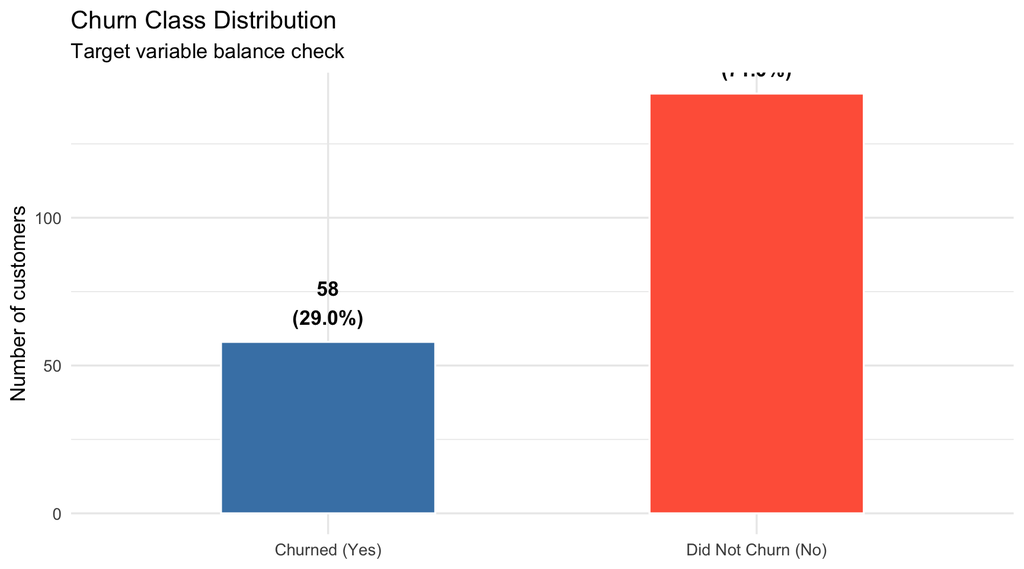

```r
# Visualise class balance — is the dataset imbalanced?
# Imbalanced classes (e.g. 95% No, 5% Yes) can bias the model toward the majority class

churn_counts <- as.data.frame(table(df$churn))
names(churn_counts) <- c("Churn", "Count")
churn_counts$Pct <- churn_counts$Count / sum(churn_counts$Count)
churn_counts$Label <- c("Did Not Churn (No)", "Churned (Yes)")

ggplot(churn_counts, aes(x = Label, y = Count, fill = Label)) +
  geom_col(width = 0.5, colour = "white") +
  geom_text(aes(label = paste0(Count, "\n(", percent(Pct, accuracy = 0.1), ")")),
            vjust = -0.4, fontface = "bold", size = 4.5) +
  scale_fill_manual(values = c("steelblue", "tomato")) +
  labs(
    title    = "Churn Class Distribution",
    subtitle = "Target variable balance check",
    x = NULL, y = "Number of customers"
  ) +
  theme_minimal(base_size = 13) +
  theme(legend.position = "none")
```

# 5 Step 4 — Feature Selection Using Correlation

**Why select features carefully?**

Including irrelevant features:

- Adds noise → hurts prediction accuracy
- Inflates the model → harder to interpret
- Can cause **multicollinearity** → correlated predictors distort coefficients

**Our strategy:**  
1. Compute point-biserial correlation (equivalent to Pearson for binary targets) of each numeric feature with the numeric `churn` values  
2. Keep features where |correlation| > 0.10  
3. Inspect a heatmap for multicollinearity among the selected features

```r
# Convert churn back to numeric temporarily for correlation computation
churn_numeric <- as.numeric(df$churn) - 1   # Yes=1, No=0

# Compute correlations of all numeric features with churn
numeric_cols <- df %>%
  select(where(is.numeric)) %>%
  names()

corr_with_churn <- sapply(numeric_cols, function(col) {
  cor(df[[col]], churn_numeric, use = "complete.obs")
})

# Sort by absolute value
corr_df <- tibble(
  Feature     = names(corr_with_churn),
  Correlation = corr_with_churn
) %>%
  arrange(desc(abs(Correlation)))

cat("Pearson Correlation with 'churn' (sorted by |r|):\n")
```

```
Pearson Correlation with 'churn' (sorted by |r|):
```

```r
corr_df %>%
  mutate(Correlation = round(Correlation, 3)) %>%
  kable(caption = "Feature correlations with churn") %>%
  kable_styling(bootstrap_options = c("striped", "hover"), full_width = FALSE)
```

Feature correlations with churn

| Feature | Correlation |
| --- | --- |
| tenure | -0.377 |
| employ | -0.338 |
| loglong | -0.337 |
| callcard | -0.311 |
| longten | -0.295 |
| longmon | -0.292 |
| age | -0.288 |
| equip | 0.275 |
| address | -0.261 |
| equipmon | 0.255 |
| internet | 0.255 |
| ebill | 0.255 |
| cardten | -0.229 |
| ed | 0.216 |
| wiremon | 0.177 |
| cardmon | -0.177 |
| wireless | 0.174 |
| voice | 0.142 |
| pager | 0.125 |
| lninc | -0.117 |
| income | -0.091 |
| confer | -0.081 |
| logtoll | -0.070 |
| tollten | -0.059 |
| callwait | -0.053 |
| custcat | 0.015 |
| tollmon | 0.014 |

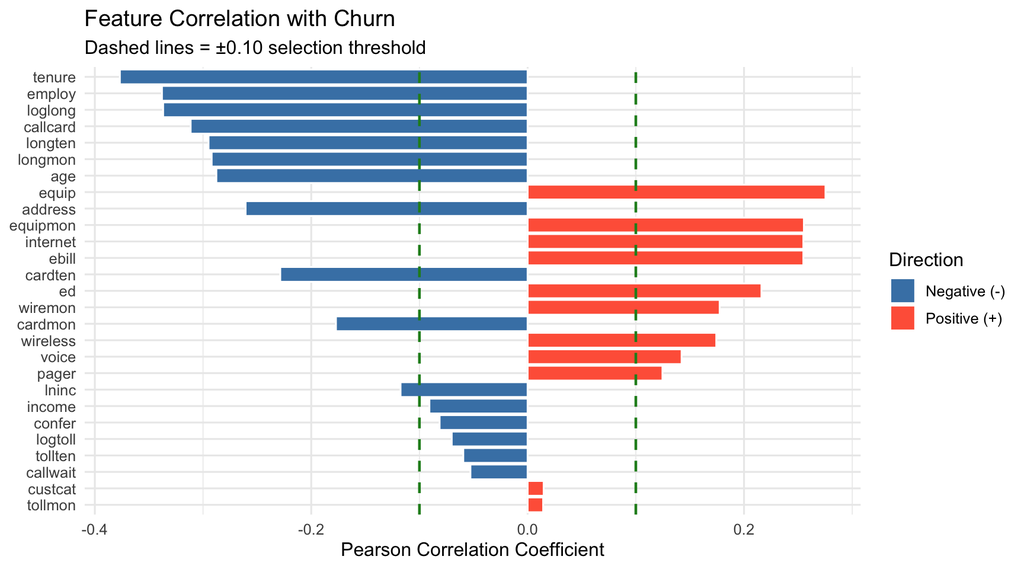

```r
# Visualise as a horizontal bar chart
corr_df_plot <- corr_df %>%
  mutate(Direction = ifelse(Correlation > 0, "Positive (+)", "Negative (-)"))

ggplot(corr_df_plot, aes(x = Correlation, y = reorder(Feature, abs(Correlation)),
                          fill = Direction)) +
  geom_col(colour = "white") +
  geom_vline(xintercept =  0.1, linetype = "dashed", colour = "forestgreen", linewidth = 0.8) +
  geom_vline(xintercept = -0.1, linetype = "dashed", colour = "forestgreen", linewidth = 0.8) +
  scale_fill_manual(values = c("Negative (-)" = "steelblue", "Positive (+)" = "tomato")) +
  labs(
    title    = "Feature Correlation with Churn",
    subtitle = "Dashed lines = ±0.10 selection threshold",
    x = "Pearson Correlation Coefficient",
    y = NULL,
    fill = "Direction"
  ) +
  theme_minimal(base_size = 12)
```

```r
# ── Apply threshold ──────────────────────────────────────────────────────────
THRESHOLD <- 0.10

selected_features <- corr_df %>%
  filter(abs(Correlation) > THRESHOLD) %>%
  pull(Feature)

cat(sprintf("Features selected (|r| > %.2f): %d\n", THRESHOLD, length(selected_features)))
```

```
Features selected (|r| > 0.10): 20
```

```r
cat(paste(selected_features, collapse = ", "), "\n")
```

```
tenure, employ, loglong, callcard, longten, longmon, age, equip, address, equipmon, internet, ebill, cardten, ed, wiremon, cardmon, wireless, voice, pager, lninc
```

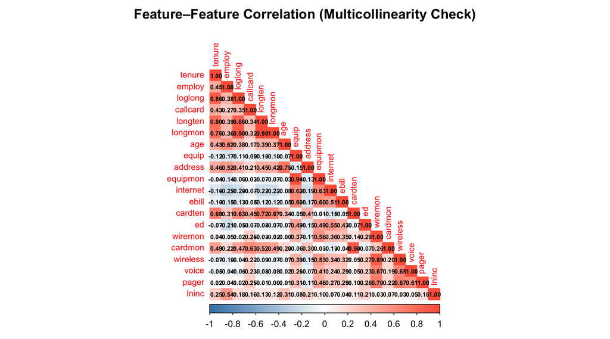

```r
# ── Check multicollinearity among selected features ──────────────────────────
# If two predictors are highly correlated WITH EACH OTHER, including both
# is redundant and distorts coefficient estimates.

feat_corr_matrix <- df %>%
  select(all_of(selected_features)) %>%
  cor(use = "complete.obs")

corrplot(
  feat_corr_matrix,
  method   = "color",
  type     = "lower",
  tl.cex   = 0.75,
  addCoef.col = "black",
  number.cex  = 0.55,
  col      = colorRampPalette(c("steelblue", "white", "tomato"))(200),
  title    = "Feature–Feature Correlation (Multicollinearity Check)",
  mar      = c(0, 0, 2, 0)
)
```

```r
# ── Remove log-transformed duplicates ────────────────────────────────────────
# 'loglong' is a log-transform of 'longmon' — they carry the same information.
# 'lninc' is a log-transform of 'income' — same.
# Keeping both inflates variance of coefficients (multicollinearity).
# We keep the more interpretable original variables.

features_to_drop  <- c("loglong", "lninc")
selected_features <- setdiff(selected_features, features_to_drop)

cat(sprintf("Final feature set (%d features):\n", length(selected_features)))
```

```
Final feature set (18 features):
```

```r
corr_df %>%
  filter(Feature %in% selected_features) %>%
  arrange(desc(abs(Correlation))) %>%
  mutate(Correlation = round(Correlation, 3),
         Direction = ifelse(Correlation > 0, "▲ increases churn", "▼ decreases churn")) %>%
  kable(caption = "Final selected features with churn correlation") %>%
  kable_styling(bootstrap_options = c("striped", "hover"), full_width = FALSE)
```

Final selected features with churn correlation

| Feature | Correlation | Direction |
| --- | --- | --- |
| tenure | -0.377 | ▼ decreases churn |
| employ | -0.338 | ▼ decreases churn |
| callcard | -0.311 | ▼ decreases churn |
| longten | -0.295 | ▼ decreases churn |
| longmon | -0.292 | ▼ decreases churn |
| age | -0.288 | ▼ decreases churn |
| equip | 0.275 | ▲ increases churn |
| address | -0.261 | ▼ decreases churn |
| equipmon | 0.255 | ▲ increases churn |
| internet | 0.255 | ▲ increases churn |
| ebill | 0.255 | ▲ increases churn |
| cardten | -0.229 | ▼ decreases churn |
| ed | 0.216 | ▲ increases churn |
| wiremon | 0.177 | ▲ increases churn |
| cardmon | -0.177 | ▼ decreases churn |
| wireless | 0.174 | ▲ increases churn |
| voice | 0.142 | ▲ increases churn |
| pager | 0.125 | ▲ increases churn |

# 6 Step 5 — Normalisation (Adjusting for Convergence)

**Why normalise?**

Logistic regression in R’s `glm()` uses **Iteratively Reweighted Least Squares (IRLS)**, which is sensitive to feature scale.

- `income` can exceed 1000
- `wireless` is binary (0 or 1)

Without normalisation, the optimiser struggles with gradient steps of wildly different magnitudes — leading to **slow or failed convergence**.

**`preProcess(method = "scale", "center")`** from `caret` applies StandardScaling:  
`z = (x - μ) / σ` → Mean = 0, SD = 1

> ⚠️ **Critical rule:** Fit the scaler on **training data only**, then apply to both train and test. Fitting on test data leaks information (“data leakage”).

```r
# ── Prepare the modelling data frame ─────────────────────────────────────────
model_df <- df %>%
  select(all_of(c(selected_features, "churn")))

# ── Stratified train/test split (80/20) ──────────────────────────────────────
# Stratified = preserves the churn proportion in both splits
set.seed(42)  # for reproducibility

train_idx <- createDataPartition(
  model_df$churn,
  p     = 0.80,
  list  = FALSE,
  times = 1
)

train_df <- model_df[ train_idx, ]
test_df  <- model_df[-train_idx, ]

cat("Training set :", nrow(train_df), "samples\n")
```

```
Training set : 161 samples
```

```r
cat("Test set     :", nrow(test_df),  "samples\n\n")
```

```
Test set     : 39 samples
```

```r
cat("Churn rate in train:", percent(mean(train_df$churn == "Yes"), 0.1), "\n")
```

```
Churn rate in train: 29.2%
```

```r
cat("Churn rate in test :", percent(mean(test_df$churn  == "Yes"), 0.1), "\n")
```

```
Churn rate in test : 28.2%
```

```r
# ── Fit the pre-processor on training data ONLY ───────────────────────────────
preproc <- preProcess(
  train_df %>% select(-churn),   # exclude the target
  method = c("center", "scale")  # center: subtract mean; scale: divide by sd
)

# ── Apply to both sets ────────────────────────────────────────────────────────
train_scaled <- predict(preproc, train_df)   # fit + transform on train
test_scaled  <- predict(preproc, test_df)    # transform only on test

# ── Verify: training feature means should be ~0, SDs ~1 ─────────────────────
post_stats <- train_scaled %>%
  select(-churn) %>%
  summarise(across(everything(), list(mean = mean, sd = sd)))

cat("Post-scaling training set verification:\n")
```

```
Post-scaling training set verification:
```

```r
means <- train_scaled %>% select(-churn) %>% summarise(across(everything(), mean))
sds   <- train_scaled %>% select(-churn) %>% summarise(across(everything(), sd))
cat(sprintf("  Grand mean of all feature means: %.6f  (should be ~0)\n", mean(unlist(means))))
```

```
  Grand mean of all feature means: -0.000000  (should be ~0)
```

```r
cat(sprintf("  Grand mean of all feature SDs  : %.6f  (should be ~1)\n", mean(unlist(sds))))
```

```
  Grand mean of all feature SDs  : 1.000000  (should be ~1)
```

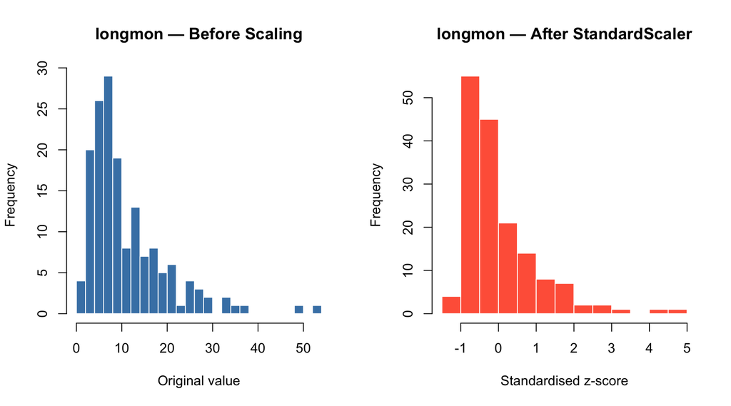

```r
# Visualise before vs after normalisation for one feature
feat <- "longmon"

before_vals <- train_df[[feat]]
after_vals  <- train_scaled[[feat]]

par(mfrow = c(1, 2))

hist(before_vals,
     main   = paste(feat, "— Before Scaling"),
     xlab   = "Original value",
     col    = "steelblue",
     border = "white",
     breaks = 20)

hist(after_vals,
     main   = paste(feat, "— After StandardScaler"),
     xlab   = "Standardised z-score",
     col    = "tomato",
     border = "white",
     breaks = 20)
```

```r
par(mfrow = c(1, 1))
```

# 7 Step 6 — Train the Logistic Regression Model

**How logistic regression works in R:**

`glm(churn ~ ., family = binomial, data = train_scaled)`

- `family = binomial` → tells `glm` to use the **logit link function** (logistic regression)
- `churn ~ .` → predict `churn` using all other columns as predictors
- Under the hood, R uses **IRLS** (Iteratively Reweighted Least Squares) to fit the coefficients

```r
# ── Train the logistic regression model ──────────────────────────────────────
# family = binomial(link = "logit") is the standard logistic regression specification
model <- glm(
  churn ~ .,
  data   = train_scaled,
  family = binomial(link = "logit")
)

cat("✅ Model trained successfully.\n\n")
```

```
✅ Model trained successfully.
```

```r
cat("Model formula: logit(P(churn=Yes)) = β₀ + β₁·feature₁ + ... + βₙ·featureₙ\n")
```

```
Model formula: logit(P(churn=Yes)) = β₀ + β₁·feature₁ + ... + βₙ·featureₙ
```

```r
# Inspect the full model output
# ── Columns explained ────────────────────────────────────────────────────────
# Estimate  : β coefficient (log-odds unit; positive = increases churn odds)
# Std. Error: uncertainty in the estimate
# z value   : Estimate / Std.Error (Wald test statistic)
# Pr(>|z|)  : p-value — small → feature is statistically significant
summary(model)
```

```
Call:
glm(formula = churn ~ ., family = binomial(link = "logit"), data = train_scaled)

Coefficients:
             Estimate Std. Error z value Pr(>|z|)
(Intercept) -1.481183   0.281372  -5.264 1.41e-07 ***
tenure      -1.025454   0.530934  -1.931   0.0534 .
employ      -0.471722   0.377430  -1.250   0.2114
callcard    -0.935115   0.394062  -2.373   0.0176 *
longten      1.204696   1.375199   0.876   0.3810
longmon     -0.650251   1.209261  -0.538   0.5908
age         -0.361140   0.408115  -0.885   0.3762
equip        0.491349   0.725955   0.677   0.4985
address      0.342190   0.403754   0.848   0.3967
equipmon    -0.157958   0.793123  -0.199   0.8421
internet     0.001752   0.302308   0.006   0.9954
ebill        0.304131   0.272921   1.114   0.2651
cardten     -0.630997   0.903174  -0.699   0.4848
ed           0.095874   0.287365   0.334   0.7387
wiremon      0.465465   0.501066   0.929   0.3529
cardmon      0.794448   0.831342   0.956   0.3393
wireless    -0.141104   0.440220  -0.321   0.7486
voice        0.085707   0.329375   0.260   0.7947
pager        0.374712   0.341393   1.098   0.2724
---
Signif. codes:  0 '***' 0.001 '**' 0.01 '*' 0.05 '.' 0.1 ' ' 1

(Dispersion parameter for binomial family taken to be 1)

    Null deviance: 194.45  on 160  degrees of freedom
Residual deviance: 134.83  on 142  degrees of freedom
AIC: 172.83

Number of Fisher Scoring iterations: 6
```

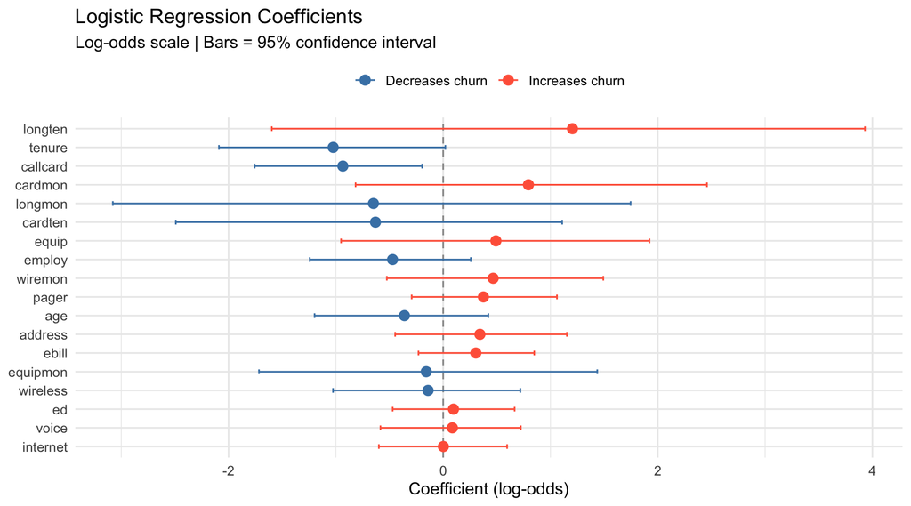

```r
# Visualise coefficients as a forest plot
coef_df <- broom::tidy(model, conf.int = TRUE) %>%
  filter(term != "(Intercept)") %>%
  arrange(desc(abs(estimate)))

ggplot(coef_df, aes(x = estimate, y = reorder(term, abs(estimate)),
                     colour = estimate > 0)) +
  geom_vline(xintercept = 0, colour = "grey60", linetype = "dashed") +
  geom_errorbarh(aes(xmin = conf.low, xmax = conf.high), height = 0.25) +
  geom_point(size = 3) +
  scale_colour_manual(values = c("FALSE" = "steelblue", "TRUE" = "tomato"),
                      labels = c("Decreases churn", "Increases churn")) +
  labs(
    title    = "Logistic Regression Coefficients",
    subtitle = "Log-odds scale | Bars = 95% confidence interval",
    x = "Coefficient (log-odds)",
    y = NULL,
    colour = NULL
  ) +
  theme_minimal(base_size = 12) +
  theme(legend.position = "top")
```

# 8 Step 7 — Model Evaluation

## 8.1 7a — Loss Function: Log-Loss (Binary Cross-Entropy)

The **loss function** is what the model minimises during training. For logistic regression, this is **log-loss** (also called binary cross-entropy):

$$\text{LogLoss} = -\frac{1}{n} \sum_{i=1}^{n} \left[ y_i \cdot \log(\hat{p}_i) + (1-y_i) \cdot \log(1-\hat{p}_i) \right]$$

- **Lower log-loss = better model**
- A random (uninformed) classifier gives log-loss ≈ **0.693** (= ln 2)
- A perfect model gives log-loss → **0**

We check it on both train and test to detect overfitting.

```r
# ── Get predicted probabilities ───────────────────────────────────────────────
# type = "response" returns P(churn=Yes) — probability on the [0,1] scale
# (using type="link" would return log-odds, not probabilities)

train_prob <- predict(model, newdata = train_scaled, type = "response")
test_prob  <- predict(model, newdata = test_scaled,  type = "response")

# Convert factor labels to 0/1 for metric functions
y_train_num <- as.numeric(train_scaled$churn) - 1
y_test_num  <- as.numeric(test_scaled$churn)  - 1

# ── Compute Log-Loss ──────────────────────────────────────────────────────────
# MLmetrics::LogLoss(predicted_probabilities, actual_labels)
train_logloss <- LogLoss(train_prob, y_train_num)
test_logloss  <- LogLoss(test_prob,  y_test_num)

cat("============================================\n")
cat(" LOSS FUNCTION — Binary Cross-Entropy (Log-Loss)\n")
```

```
 LOSS FUNCTION — Binary Cross-Entropy (Log-Loss)
```

```r
cat("============================================\n")
cat(sprintf("  Training log-loss : %.4f\n", train_logloss))
```

```
  Training log-loss : 0.4187
```

```r
cat(sprintf("  Test     log-loss : %.4f\n", test_logloss))
```

```
  Test     log-loss : 0.4745
```

```r
cat(sprintf("  Baseline (random) : 0.6931\n"))
```

```
  Baseline (random) : 0.6931
```

```r
cat("\n")
```

```r
if (test_logloss < 0.5) {
  cat("  ✅ Model is substantially better than random.\n")
} else if (test_logloss < 0.65) {
  cat("  ⚠️  Model is modestly better than random.\n")
} else {
  cat("  ❌ Model near random — revisit feature selection.\n")
}
```

```
  ✅ Model is substantially better than random.
```

```r
# ── AUC-ROC ──────────────────────────────────────────────────────────────────
# AUC = 1.0 → perfect ranking; AUC = 0.5 → random; AUC < 0.5 → worse than random

roc_obj <- roc(
  response  = test_scaled$churn,
  predictor = test_prob,
  levels    = c("No", "Yes"),
  direction = "<"    # higher probability → more likely "Yes" (churn)
)

auc_val <- auc(roc_obj)
cat(sprintf("AUC-ROC Score: %.4f\n", auc_val))
```

```
AUC-ROC Score: 0.8149
```

[figure not shown]

```r
# Plot ROC curve
plot(
  roc_obj,
  col     = "tomato",
  lwd     = 2,
  main    = sprintf("ROC Curve — Churn Prediction  (AUC = %.3f)", auc_val),
  xlab    = "False Positive Rate (1 - Specificity)",
  ylab    = "True Positive Rate (Sensitivity / Recall)"
)
abline(a = 0, b = 1, lty = 2, col = "grey50")
legend("bottomright",
       legend = c(sprintf("Logistic Regression (AUC=%.3f)", auc_val), "Random classifier"),
       col    = c("tomato", "grey50"),
       lwd    = c(2, 1),
       lty    = c(1, 2))
```

```r
# ── Hard predictions using 0.5 threshold ─────────────────────────────────────
# If P(churn) > 0.5 → predict "Yes", else "No"
test_pred <- ifelse(test_prob > 0.5, "Yes", "No") %>%
  factor(levels = c("No", "Yes"))

# ── Confusion Matrix ──────────────────────────────────────────────────────────
# caret's confusionMatrix gives a rich summary with many derived metrics
cm <- confusionMatrix(
  data      = test_pred,
  reference = test_scaled$churn,
  positive  = "Yes"     # "Yes" = churn is the "positive" class
)

print(cm)
```

```
Confusion Matrix and Statistics

          Reference
Prediction No Yes
       No  24   7
       Yes  4   4

               Accuracy : 0.7179
                 95% CI : (0.5513, 0.85)
    No Information Rate : 0.7179
    P-Value [Acc > NIR] : 0.5804

                  Kappa : 0.2407

 Mcnemar's Test P-Value : 0.5465

            Sensitivity : 0.3636
            Specificity : 0.8571
         Pos Pred Value : 0.5000
         Neg Pred Value : 0.7742
             Prevalence : 0.2821
         Detection Rate : 0.1026
   Detection Prevalence : 0.2051
      Balanced Accuracy : 0.6104

       'Positive' Class : Yes
```

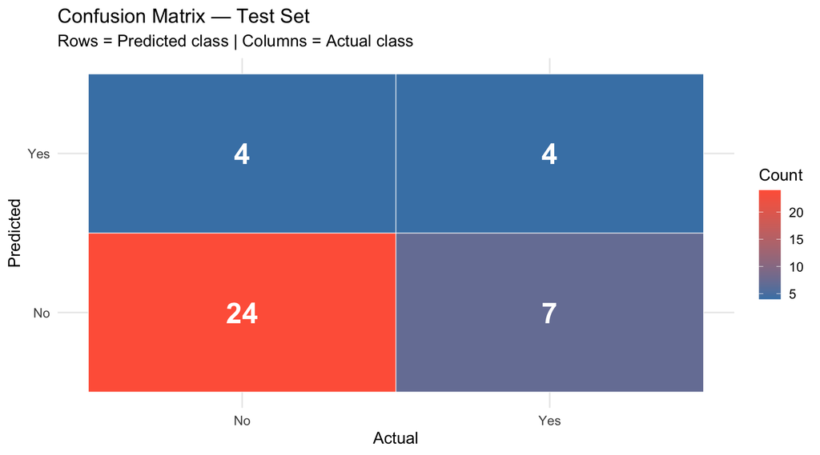

```r
# Visualise confusion matrix as a heatmap
cm_table <- as.data.frame(cm$table)
names(cm_table) <- c("Predicted", "Actual", "Count")

ggplot(cm_table, aes(x = Actual, y = Predicted, fill = Count)) +
  geom_tile(colour = "white") +
  geom_text(aes(label = Count), size = 8, fontface = "bold", colour = "white") +
  scale_fill_gradient(low = "steelblue", high = "tomato") +
  labs(
    title    = "Confusion Matrix — Test Set",
    subtitle = "Rows = Predicted class | Columns = Actual class",
    fill     = "Count"
  ) +
  theme_minimal(base_size = 13)
```

# 9 Step 8 — Summary & Interpretation

```r
accuracy  <- cm$overall["Accuracy"]
precision <- cm$byClass["Precision"]
recall    <- cm$byClass["Recall"]
f1        <- cm$byClass["F1"]

cat("==============================================\n")
cat(" CHURN PREDICTION MODEL — FINAL SUMMARY\n")
```

```
 CHURN PREDICTION MODEL — FINAL SUMMARY
```

```r
cat("==============================================\n")
cat(sprintf("  Dataset           : %d customers, %d columns\n", nrow(df), ncol(df)))
```

```
  Dataset           : 200 customers, 28 columns
```

```r
cat(sprintf("  Features used     : %d\n", length(selected_features)))
```

```
  Features used     : 18
```

```r
cat(sprintf("  Train / Test split: 80%% / 20%% (stratified)\n\n"))
```

```
  Train / Test split: 80% / 20% (stratified)
```

```r
cat("  ─── Performance Metrics ───\n")
```

```
  ─── Performance Metrics ───
```

```r
cat(sprintf("  Test Accuracy  : %.1f%%\n",  accuracy  * 100))
```

```
  Test Accuracy  : 71.8%
```

```r
cat(sprintf("  Test Precision : %.1f%%\n",  precision * 100))
```

```
  Test Precision : 50.0%
```

```r
cat(sprintf("  Test Recall    : %.1f%%\n",  recall    * 100))
```

```
  Test Recall    : 36.4%
```

```r
cat(sprintf("  Test F1-Score  : %.3f\n",    f1))
```

```
  Test F1-Score  : 0.421
```

```r
cat(sprintf("  Test Log-Loss  : %.4f  (lower = better)\n", test_logloss))
```

```
  Test Log-Loss  : 0.4745  (lower = better)
```

```r
cat(sprintf("  Test AUC-ROC   : %.4f  (1.0 = perfect)\n", auc_val))
```

```
  Test AUC-ROC   : 0.8149  (1.0 = perfect)
```

```r
cat("\n")
```

```r
cat("  ─── Steps Taken ───\n")
```

```
  ─── Steps Taken ───
```

```r
cat("  1. Loaded 200-customer telecom dataset\n")
```

```
  1. Loaded 200-customer telecom dataset
```

```r
cat("  2. Converted 'churn' to factor (categorical) for glm()\n")
```

```
  2. Converted 'churn' to factor (categorical) for glm()
```

```r
cat("  3. Selected features with |Pearson r| > 0.10\n")
```

```
  3. Selected features with |Pearson r| > 0.10
```

```r
cat("  4. Removed collinear log-transformed duplicates\n")
```

```
  4. Removed collinear log-transformed duplicates
```

```r
cat("  5. Normalised with caret::preProcess (center + scale)\n")
```

```
  5. Normalised with caret::preProcess (center + scale)
```

```r
cat("  6. Trained glm() with family=binomial(link='logit')\n")
```

```
  6. Trained glm() with family=binomial(link='logit')
```

```r
cat("  7. Evaluated via log-loss, AUC-ROC, confusion matrix\n")
```

```
  7. Evaluated via log-loss, AUC-ROC, confusion matrix
```

```r
cat("==============================================\n")
```

# 10 📚 Key Concepts Recap

[output not shown]

**Next steps to explore:**

- Use `class.weights` in `caret::train()` to handle class imbalance
- Try **stepwise selection** with `step(model, direction="both")` for formal feature selection
- Add L1 (LASSO) regularisation via `glmnet` package for automatic sparsity
- Compare with `randomForest` or `xgboost` on the same feature set

*End of notebook. Happy modelling! 🎉*